# Investigating Perturbations to Wnt Gradient

Axel Almet

6 March 2018

## From the Literature

According to Sansom et al. (2004), loss of the Wnt-regulating APC gene disrupts the Wnt gradient, affecting proliferation, migration, and the pattern of differentiation on a short time scale (five days). Moreover, Park et al. (1998) established that loss of the APC gene results in disregulation of crypt fission. Therefore, we will test whether or not dynamically manipulating the Wnt gradient is enough to disrupt an established crypt shape.

## Set-up

We consider purely biochemical growth of the form

$$\frac{\dot{\gamma}}{\gamma} = \eta W(S_0),$$
where $W(S_0)$ represents the distribution of a chemical signal (Wnt) and is given by

$$W(S_0) = \exp\left({-\frac{\left(S_0 - 0.5L_0\right)^2}{\sigma^2}}\right).$$

The growth rate parameter $\eta$ is set to $\eta = (\int^{L_0}_0W(S_0)dS_0)^{-1}$ for all values of $\sigma$, so as to maintain a fixed ‘amount’ of Wnt in the system. We explore the effect of dynamically increasing $\sigma$ once a crypt shape has been established. The rod is assumed to be inextensible for all cases.

We first set $\sigma = 0.1L_0$, which results in a reasonable crypt shape.

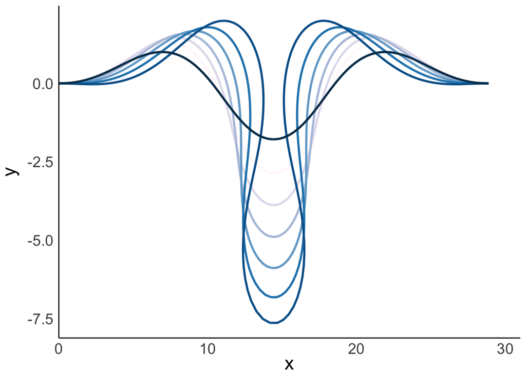

For reference, this is what the shape would look like if we had set $\sigma = 0.5L_0$.

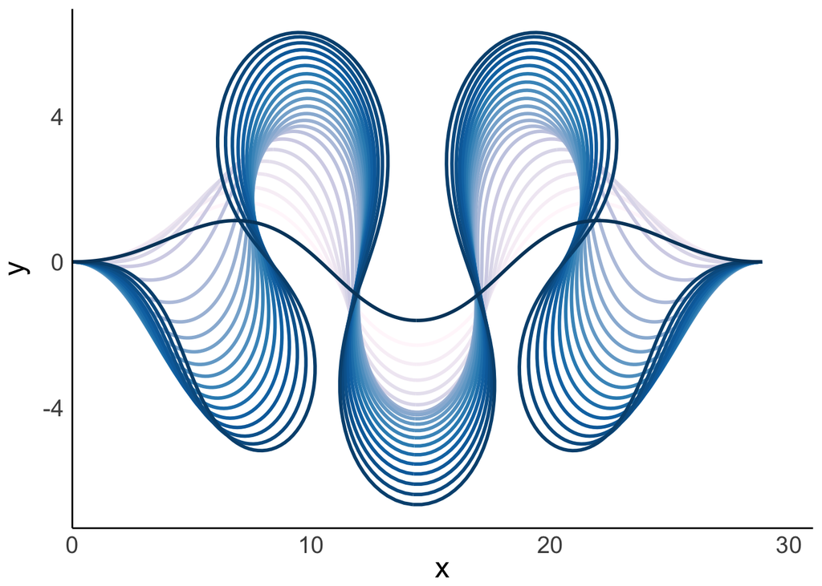

## Results

With the crypt shape, we now set $\sigma = 0.5L_0$ and let the rod grow again.

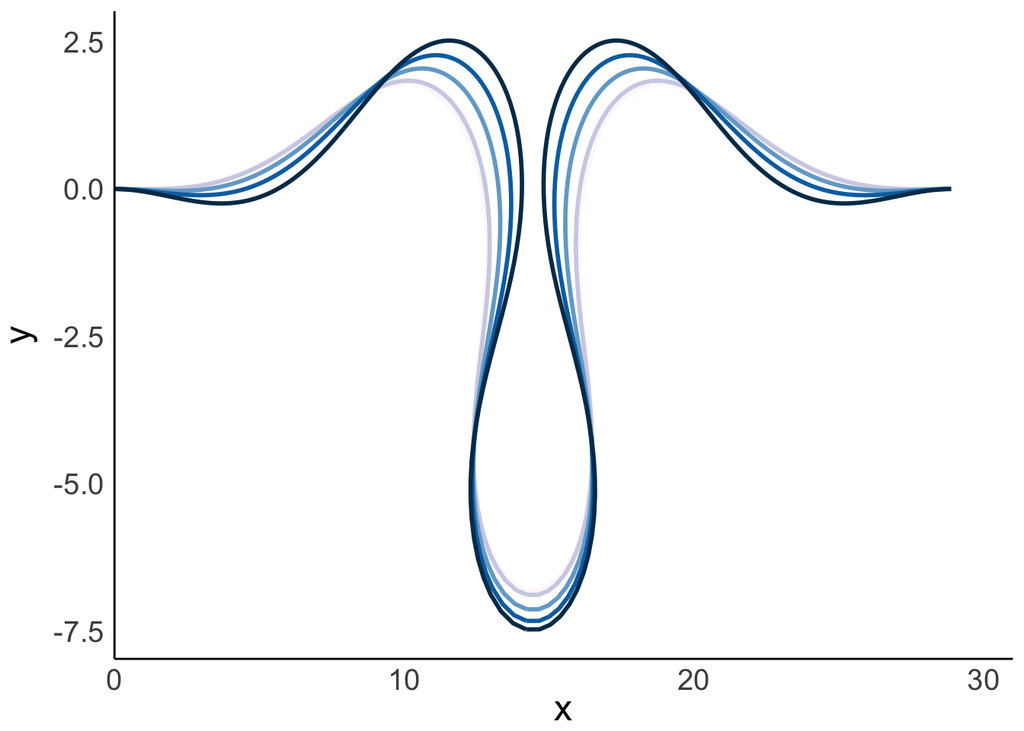

Increasing $\sigma$ does not seem to distort the shape as much as we had hoped. Part of this can be explained by looking at the profile of $\gamma$ after we have altered $\sigma$, revealing that while we have increased the width of the $W(S_0)$, growth itself does not change that much.

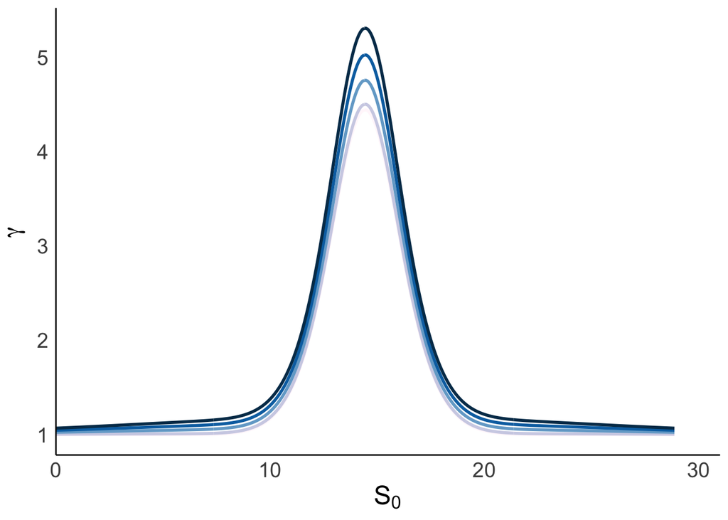

Even if we increase the amount of Wnt, by setting $\eta = 7\left(\int^{L_0}_0W(S_0)dS_0\right)^{-1}$, we see negligible change:

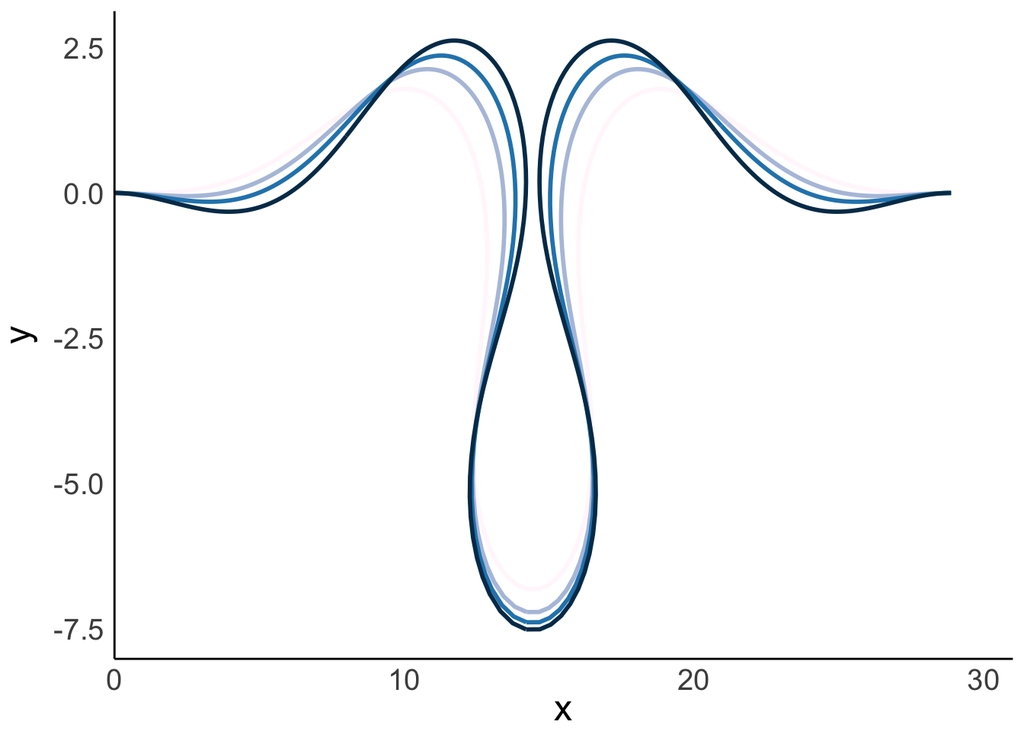

## Conclusions

This suggests that there are other subcellular and cellular that are necessary to distort the tissue shape. Indeed, in Sansom et al. (2004), the authors note,

> Changes were also observed in the extracellular matrix proteins, including laminin $\alpha 1$ and $\alpha 2$, laminin $\gamma 2$, tenascin and perlacan (Supplementary Fig. 2). These findings indicate that loss of APC in the epithelium also has an immediate effect on the surrounding mesenchyme’.